# DS 220 Final Project: Student Performance and Learning Style Analysis

**Author**: Anjola Ajibola

**Course**: DS 220 - Data Analysis with Python

**Project Goal**: This project explores how students' learning habits, preferences, and behaviors influence their academic performance using Python and Pandas. We analyze a dataset of student performance and learning styles and derive actionable insights to better support students.

## Research Questions

We will investigate the following questions:

1. Is there a significant relationship between students’ learning styles and their academic performance?
2. What is the distribution of students' final grades (A, B, C, D, F)?
3. How does the number of study hours per week relate to the final exam score?
4. Does participating in discussions impact assignment completion rate and exam scores?
5. How does use of educational technology affect exam scores?
6. What is the correlation between time spent on social media and exam scores?

```python
import pandas as pd
import matplotlib.pyplot as plt
import seaborn as sns
```

```python
# Load the dataset
import pandas as pd
df = pd.read_csv("student_performance_large_dataset.csv")
# Display first few rows
df.head()
```

[output not shown]

## Preprocessing and Cleaning

- Check dataset shape
- Check data types
- Check missing values
- Basic cleaning if needed

```python
# Dataset shape
print(f"Dataset shape: {df.shape}")

# Data types
print("\nData types:")
print(df.dtypes)

# Missing values
print("\nMissing values:")
print(df.isnull().sum())
```

```
Dataset shape: (10000, 15)

Data types:
Student_ID                                 object
Age                                         int64
Gender                                     object
Study_Hours_per_Week                        int64
Preferred_Learning_Style                   object
Online_Courses_Completed                    int64
Participation_in_Discussions               object
Assignment_Completion_Rate (%)              int64
Exam_Score (%)                              int64
Attendance_Rate (%)                         int64
Use_of_Educational_Tech                    object
Self_Reported_Stress_Level                 object
Time_Spent_on_Social_Media (hours/week)     int64
Sleep_Hours_per_Night                       int64
Final_Grade                                object
dtype: object

Missing values:
Student_ID                                 0
Age                                        0
Gender                                     0
Study_Hours_per_Week                       0
Preferred_Learning_Style                   0
Online_Courses_Completed                   0
Participation_in_Discussions               0
Assignment_Completion_Rate (%)             0
Exam_Score (%)                             0
Attendance_Rate (%)                        0
Use_of_Educational_Tech                    0
Self_Reported_Stress_Level                 0
Time_Spent_on_Social_Media (hours/week)    0
Sleep_Hours_per_Night                      0
Final_Grade                                0
dtype: int64
```

## Exploratory Data Analysis (EDA)

- Distribution of key features
- Descriptive statistics
- Basic visualizations

```python
# Descriptive statistics
df.describe(include='all')
```

|  | Student_ID | Age | Gender | Study_Hours_per_Week | Preferred_Learning_Style | Online_Courses_Completed | Participation_in_Discussions | Assignment_Completion_Rate (%) | Exam_Score (%) | Attendance_Rate (%) | Use_of_Educational_Tech | Self_Reported_Stress_Level | Time_Spent_on_Social_Media (hours/week) | Sleep_Hours_per_Night | Final_Grade |
| --- | --- | --- | --- | --- | --- | --- | --- | --- | --- | --- | --- | --- | --- | --- | --- |
| count | 10000 | 10000.000000 | 10000 | 10000.000000 | 10000 | 10000.000000 | 10000 | 10000.000000 | 10000.000000 | 10000.000000 | 10000 | 10000 | 10000.000000 | 10000.000000 | 10000 |
| unique | 10000 | NaN | 3 | NaN | 4 | NaN | 2 | NaN | NaN | NaN | 2 | 3 | NaN | NaN | 4 |
| top | S09984 | NaN | Female | NaN | Visual | NaN | Yes | NaN | NaN | NaN | Yes | Medium | NaN | NaN | A |
| freq | 1 | NaN | 4846 | NaN | 2523 | NaN | 5996 | NaN | NaN | NaN | 7022 | 5015 | NaN | NaN | 2678 |
| mean | NaN | 23.478800 | NaN | 27.130300 | NaN | 10.007900 | NaN | 74.922000 | 70.188900 | 75.085100 | NaN | NaN | 14.936500 | 6.979300 | NaN |
| std | NaN | 3.461986 | NaN | 13.002547 | NaN | 6.136726 | NaN | 14.675437 | 17.649447 | 14.749251 | NaN | NaN | 9.022639 | 1.996965 | NaN |
| min | NaN | 18.000000 | NaN | 5.000000 | NaN | 0.000000 | NaN | 50.000000 | 40.000000 | 50.000000 | NaN | NaN | 0.000000 | 4.000000 | NaN |
| 25% | NaN | 20.000000 | NaN | 16.000000 | NaN | 5.000000 | NaN | 62.000000 | 55.000000 | 62.000000 | NaN | NaN | 7.000000 | 5.000000 | NaN |
| 50% | NaN | 23.000000 | NaN | 27.000000 | NaN | 10.000000 | NaN | 75.000000 | 70.000000 | 75.000000 | NaN | NaN | 15.000000 | 7.000000 | NaN |
| 75% | NaN | 27.000000 | NaN | 38.000000 | NaN | 15.000000 | NaN | 88.000000 | 85.000000 | 88.000000 | NaN | NaN | 23.000000 | 9.000000 | NaN |
| max | NaN | 29.000000 | NaN | 49.000000 | NaN | 20.000000 | NaN | 100.000000 | 100.000000 | 100.000000 | NaN | NaN | 30.000000 | 10.000000 | NaN |

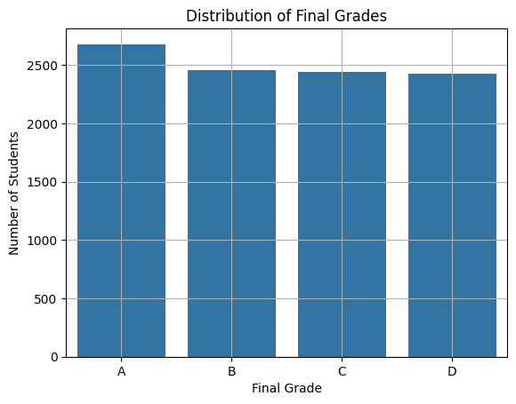

```python
# Distribution of Final Grades
sns.countplot(x='Final_Grade', data=df, order=sorted(df['Final_Grade'].unique()))
plt.title('Distribution of Final Grades')
plt.xlabel('Final Grade')
plt.ylabel('Number of Students')
plt.grid(True)
plt.show()
```

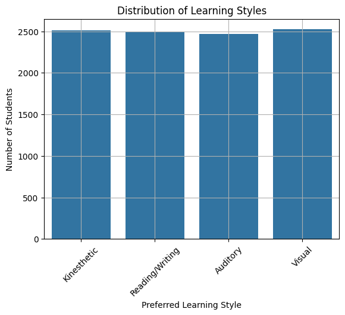

```python
# Distribution of Learning Styles
sns.countplot(x='Preferred_Learning_Style', data=df)
plt.title('Distribution of Learning Styles')
plt.xlabel('Preferred Learning Style')
plt.ylabel('Number of Students')
plt.xticks(rotation=45)
plt.grid(True)
plt.show()
```

## Problem 1: Learning Styles vs Academic Performance

Is there a significant relationship between students’ learning styles and academic performance?

```
Preferred_Learning_Style
Auditory           70.493106
Kinesthetic        70.348189
Visual             70.105826
Reading/Writing    69.812250
Name: Exam_Score (%), dtype: float64
```

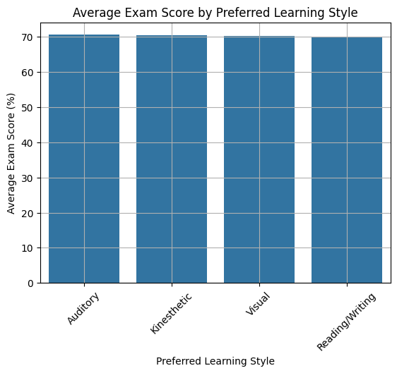

```python
learning_style_performance = df.groupby('Preferred_Learning_Style')['Exam_Score (%)'].mean().sort_values(ascending=False)
print(learning_style_performance)

sns.barplot(x=learning_style_performance.index, y=learning_style_performance.values)
plt.title('Average Exam Score by Preferred Learning Style')
plt.xlabel('Preferred Learning Style')
plt.ylabel('Average Exam Score (%)')
plt.xticks(rotation=45)
plt.grid(True)
plt.show()
```

**Insight:** The average exam scores for different learning styles were all really close, with only a small difference of about 1%. This suggests that learning style doesn’t have much effect on exam performance in this dataset.

## Problem 2: Distribution of Final Grades

What is the distribution of students' final grades (A, B, C, D, F)?

```
Final_Grade
A    2678
B    2455
C    2440
D    2427
Name: count, dtype: int64
```

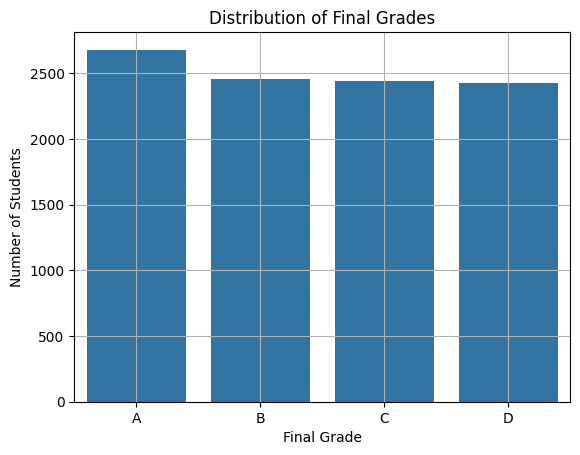

```python
grade_distribution = df['Final_Grade'].value_counts().sort_index()
print(grade_distribution)

sns.countplot(x='Final_Grade', data=df, order=sorted(df['Final_Grade'].unique()))
plt.title('Distribution of Final Grades')
plt.xlabel('Final Grade')
plt.ylabel('Number of Students')
plt.grid(True)
plt.show()
```

**Insight:** The final grades were spread out quite evenly, though slightly more students got A’s. Overall, the distribution looks balanced and doesn’t show any major trends toward one grade.

## Question 3: Study Hours vs Exam Score

How does the number of study hours per week relate to the final exam score?

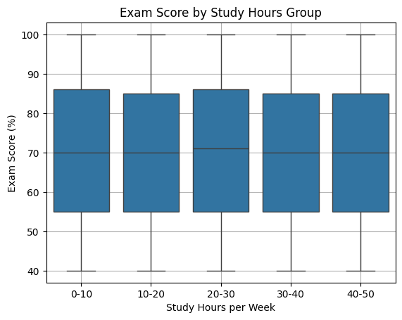

```
Correlation: 0.00
```

```python
# Bin study hours into groups
bins = [0, 10, 20, 30, 40, 50]
labels = ['0-10', '10-20', '20-30', '30-40', '40-50']
df['Study_Hours_Group'] = pd.cut(df['Study_Hours_per_Week'], bins=bins, labels=labels)

# Boxplot
sns.boxplot(x='Study_Hours_Group', y='Exam_Score (%)', data=df)
plt.title('Exam Score by Study Hours Group')
plt.xlabel('Study Hours per Week')
plt.ylabel('Exam Score (%)')
plt.grid(True)
plt.show()

# Correlation
correlation = df['Study_Hours_per_Week'].corr(df['Exam_Score (%)'])
print(f'Correlation: {correlation:.2f}')
```

**Insight:** I expected students who studied more to score higher, but the results didn’t really show that. The box plots looked almost the same for all groups, and the correlation was basically zero; so study hours didn’t seem to affect scores much in this case.

## Problem 4: Discussion Participation Impact

Does participating in discussions impact assignment completion rate and exam scores?

```
                              Assignment_Completion_Rate (%)  Exam_Score (%)
Participation_in_Discussions
No                                                 74.934565       70.155345
Yes                                                74.913609       70.211308
```

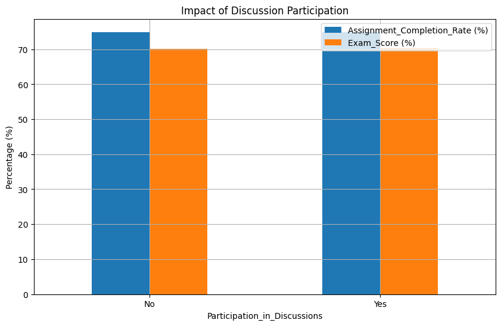

```python
discussion_impact = df.groupby('Participation_in_Discussions')[['Assignment_Completion_Rate (%)', 'Exam_Score (%)']].mean()
print(discussion_impact)

discussion_impact.plot(kind='bar', figsize=(10,6))
plt.title('Impact of Discussion Participation')
plt.ylabel('Percentage (%)')
plt.xticks(rotation=0)
plt.grid(True)
plt.show()
```

**Insight:** Students who said they participate in discussions had about the same exam scores and assignment completion rates as those who didn’t. So, being active in discussions didn’t seem to make a big difference in performance.

## Problem 5: Educational Technology Use

How does use of educational technology affect exam scores?

```
Use_of_Educational_Tech
No     70.337139
Yes    70.126032
Name: Exam_Score (%), dtype: float64
```

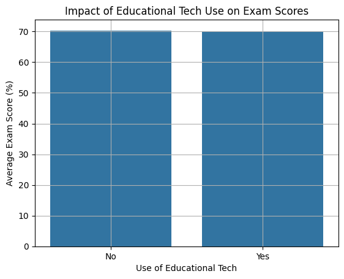

```python
edtech_impact = df.groupby('Use_of_Educational_Tech')['Exam_Score (%)'].mean()
print(edtech_impact)

sns.barplot(x=edtech_impact.index, y=edtech_impact.values)
plt.title('Impact of Educational Tech Use on Exam Scores')
plt.xlabel('Use of Educational Tech')
plt.ylabel('Average Exam Score (%)')
plt.grid(True)
plt.show()
```

**Insight:** I thought using educational tech might help students, but both groups had almost the same average exam scores. There wasn’t really a clear advantage for those using tech.

## Question 6: Social Media Time vs Exam Score

What is the correlation between time spent on social media and exam scores?

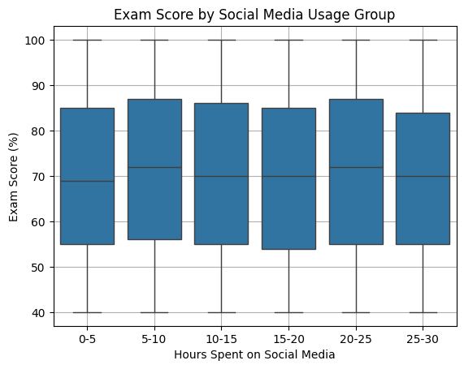

```
Correlation: 0.00
```

```python
# Bin social media hours into groups
bins = [0, 5, 10, 15, 20, 25, 30]
labels = ['0-5', '5-10', '10-15', '15-20', '20-25', '25-30']
df['Social_Media_Group'] = pd.cut(df['Time_Spent_on_Social_Media (hours/week)'], bins=bins, labels=labels)

# Boxplot
sns.boxplot(x='Social_Media_Group', y='Exam_Score (%)', data=df)
plt.title('Exam Score by Social Media Usage Group')
plt.xlabel('Hours Spent on Social Media')
plt.ylabel('Exam Score (%)')
plt.grid(True)
plt.show()

# Correlation
correlation_social = df['Time_Spent_on_Social_Media (hours/week)'].corr(df['Exam_Score (%)'])
print(f'Correlation: {correlation_social:.2f}')
```

**Insight:** I assumed students who spent a lot of time on social media might score lower, but the data didn’t show that. The scores were similar across all usage levels, and there wasn’t any obvious trend or strong correlation.

## Conclusion

At first, I expected to see some strong patterns, like better scores from students who study more or use tech. But honestly, most of the factors I looked at didn’t seem to have much impact on performance. This makes me think that there are probably other things, like personal motivation or course difficulty, that matter more than just habits like tech use or study hours.